# Lab 1 - Checkpoint 2 - Minhas perguntas

```r
library(tidyverse)
library(here)
library(knitr)
theme_set(theme_bw())
```

```r
projetos = read_csv(here::here("data/projetos.csv")) %>%
    filter(lang != 'javascript')
```

### 1. Definição das variáveis

Com o objetivo de responder às seguintes perguntas; a) Como são os tamanhos de time nos projetos que usam travis em Java e em Ruby nos nossos dados?; b) Ao comparar projetos em Java e em Ruby que tenham ao menos 10 contribuidores no time nos nossos dados, projetos de qual linguagem variam mais na proporção de builds cujo resultado é sucesso? Foram selecionadas as seguintes variáveis do dataset (projetos.csv) disponibilizado:

```
lang = linguagem de programação
team = tamanho do time de desenvolvedores
build_success_prop = proporção de sucesso dos build
```

Nesse contexto, a fim de analisar a variável lang, a figura abaixo expõe a proporção de projetos Java e Ruby contidos no dataset. Para esta análise foram desconsiderados dados de projetos desenvolvidos em outra linguagem devido ao objetivo do relatório serem direcionados para essas duas linguagens de programação.

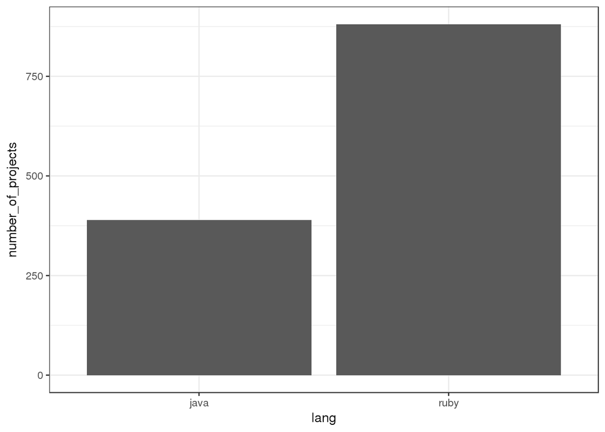

```r
projetos %>%
    group_by(lang) %>%
    summarise(number_of_projects = n()) %>%
    ggplot(aes(x = lang, y = number_of_projects)) +
    geom_col()
```

De acordo com a figura existem nos dados mais de 750 projetos com a linguagem de programação Ruby e aproximadamente 375 projetos Java. Esta variável é de centro, pois representa uma contagem de projetos. Além disso, ela é uma variável simétrica, estando concentrada entre 1 e aproximadamente 750.

No que se refere a variável team (time), a figura abaixo mostra a relação entre o número de projetos e a proporção do número de integrantes dos times desses projetos.

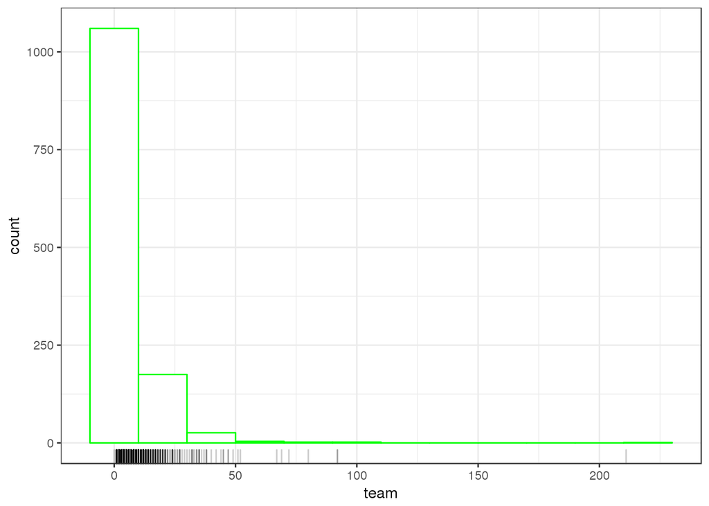

```r
projetos %>%
    ggplot(aes(x = team)) +
    geom_histogram(binwidth = 20, fill = "white", color = "green") +
    geom_rug(alpha = .2)
```

Com base na Figura acima, é possível identificar a existência de uma alta concentração de projetos com times entre 1 a 50 integrantes, estando nessa faixa de valores a maior quantidade de projetos contidos nos dados. Além disso, é notável que os dados da variável team não são simetricamente distribuídos.

Considerando valores extremos, é apresentado nos dados apenas uma projeto que possui em sua composição um time com mais de 200 integrantes. Este projeto trata-se de um popular framework web para a linguagem de programação Ruby denominado Rails. Esta popularidade do framework pode ser o motivo da presença de grande número de contribuintes no projeto.

Na figura abaixo é exibida a proporção de projetos em relação aos seus builds sucesso.

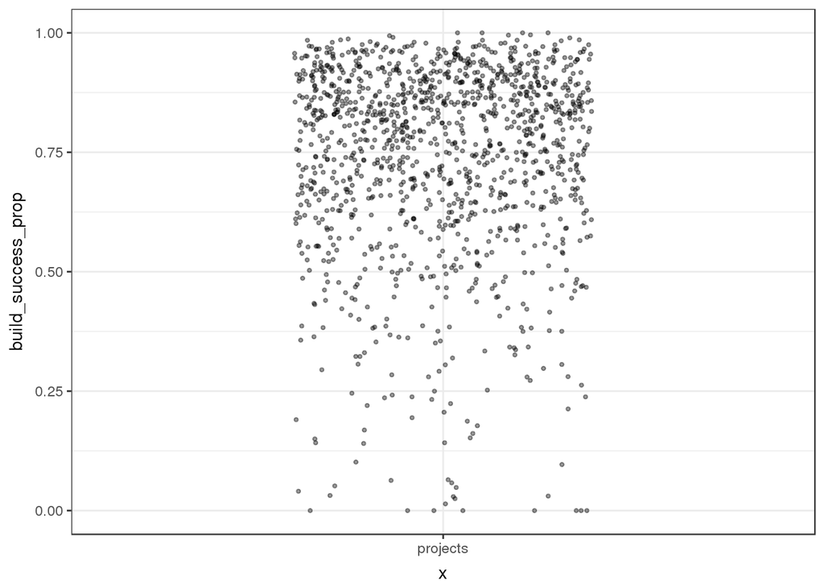

```r
projetos %>%
    ggplot(aes(y = build_success_prop , x ='projects')) +
    geom_jitter(alpha = .4, width = .2, size = .8)
```

Com base na figura acima, fica evidente a grande dispersão da proporção de builds sucessos nos projetos. Nesse contexto, existem projetos com taxa de builds sucesso perto do limite inferior (0) e também projetos que passaram a maior parte do tempo com a build com status de sucesso, estando dispostos próximo ao limite superior (1). No entanto, existe uma concetração maior de projetos entre as faixas de valores entre 0.75 e 1. Assim, é possível verificar que dados não são totalmente simétricos.

### 2. Tamanho dos times e linguagens utilizadas

Na figura abaixo, é apresentado a proporção dos projetos e o tamanho de seus times.

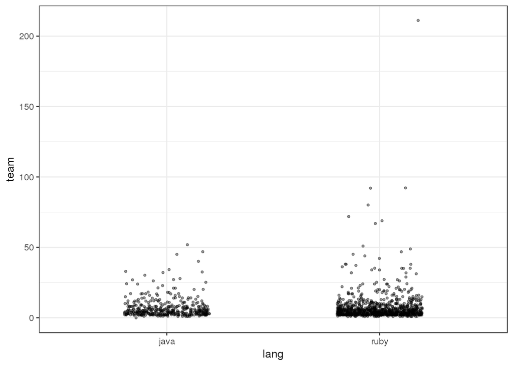

```r
projetos %>%
    ggplot(aes(x = lang, y = team)) +
    geom_jitter(alpha = .4, width = .2, size = .8)
```

Com base na análise da figura exibida acima, é possível apontar que a proporção de projetos Ruby e maior em comparação aos de linguagem Java. Além disso, considerando somente os projetos Java, podemos verificar que somente um projeto possui equipe superior a 50 colaboradores, o restante do projetos possuem entre 1 a 50 desenvolvedores. No mais, apesar de existirem projetos Ruby com equipes superiores a 50 pessoas, a maior concentração de projetos fica como nos projetos Java entre 1 a 50 membros.

### 3. Proporção de sucesso nos builds relacionando com a Linguagem do projeto

Considerando os projetos com times superiores a 9 integrantes a figura abaixo apresenta a proporção dos projetos em relação a sua linguagem e sua proporção de builds com sucesso.

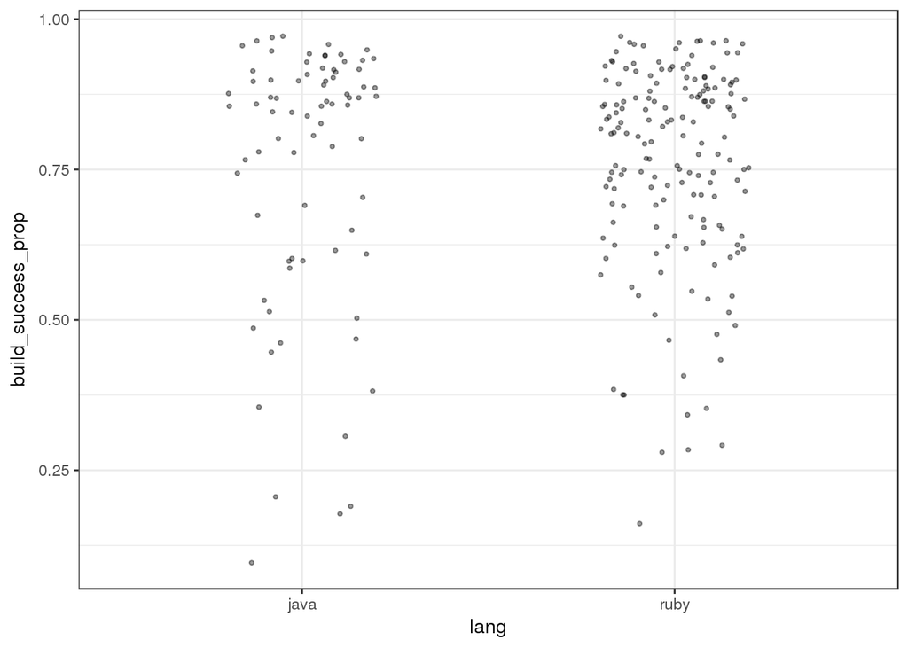

```r
projetos %>%
    filter(team > 9) %>%
    ggplot(aes(x = lang, y = build_success_prop)) +
    geom_jitter(alpha = .4, width = .2, size = .8)
```